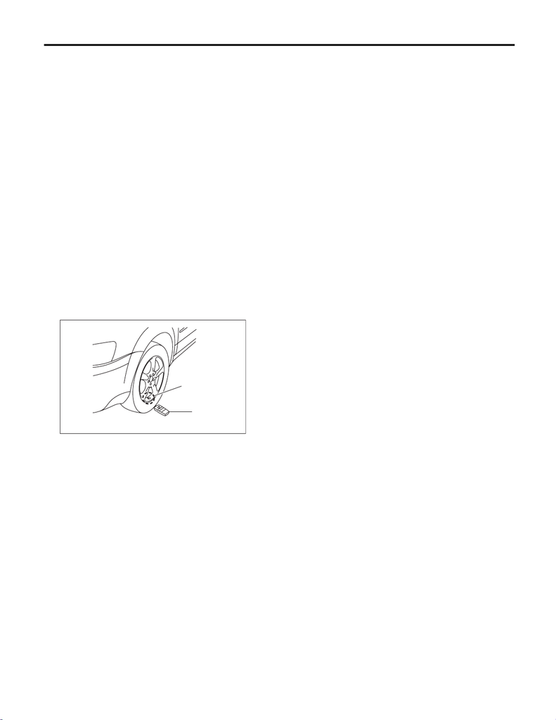

Register Transmitter (ID)

TIRE PRESSURE MONITORING SYSTEM (DIAGNOSTICS)

9. Register Transmitter (ID)

A: OPERATION

Perform the registration procedure of the transmitter in the following cases:

• Transmitter was replaced.

• TPMS & keyless entry CM or TPMS CM is replaced.

NOTE:

• If registration of the transmitter ID is not possible after two attempts, replace the TPMS & keyless entry CM

or TPMS CM. <Ref. to WT-9, Tire Pressure Monitoring System.>

• During the registration, turn the ignition switch to OFF and end the Subaru Select Monitor. Or if the regis-

tration is not performed for 5 minutes or more, the registration mode is cancelled.

• When rotating tires, there is no affect on the performance or functions of the tire pressure monitoring con-

trol module even if the transmitter (ID) is not registered, however, the tire position displayed on the Subaru

Select Monitor will be incorrect.

1) Adjust all tire pressures to the specifications.

2) Connect Subaru Select Monitor and select the {Each System Check} on the «Main Menu».

3) On «System Selection Menu» display, select {Tire pressure monitor}.

4) After the {Tire pressure monitor} is displayed, select [OK].

5) On «Tire pressure monitor diagnosis» display, select {Transmitter ID regist confirm}.

6) {ID registration mode When execute Registered ID is deleted Continue?} is displayed, select [OK].

7) Contact the transmitter registration tool to the side wall area near the air valve on the front left tire, and

press the switch. The transmitter ID is sent to the TPMS & keyless entry CM or TPMS CM. (At this time, the

tire pressure warning light blinks to confirm that the registration has started.)

NOTE:

• The registration order of transmitter ID is not specified.

• The transmitter registration tool is used by touching the side wall area near the transmitter.

• When registration of each tire is completed, {ID registration completed} is displayed on the Select Monitor

screen.

• If registration procedure stop in the halfway (turning ignition switch to OFF, wrong registration order, etc),

proceed from step 5).

8) When ID registration is completed, the tire pressure warning light remains lit for approximately 2 seconds,

to end the registration. Switch to the screen displaying the transmitter ID on the Subaru Select Monitor dis-

play. <Ref. to TPM(diag)-15, Display Transmitter (ID).>

9) Check the transmitter ID that was registered, then perform a driving test. <Ref. to TPM(diag)-16, Inspec-

tion Mode.>

(1)

(2)

TPM00006

(1) Air valve (transmitter)

(2) Transmitter registration tool